# Supplementary Materials: Search strategies improve with practice, but not with time pressure or financial incentives

ADF Clarke

30/06/2020

These supplementary materials contain more details of the Bayesian analysis, including power analysis. Please see the source Rmd file for full code.

# 1 Experiment 1: Deadline

We will first look at descriptive statistics for accuracy and reaction time data, to check that it looks sensible and inline with our expectations.

## 1.1 Descriptive Statistics

### 1.1.1 Accuracy and Reaction Time

After plotting the accuracy data, incorrect trials are removed from all further analysis.

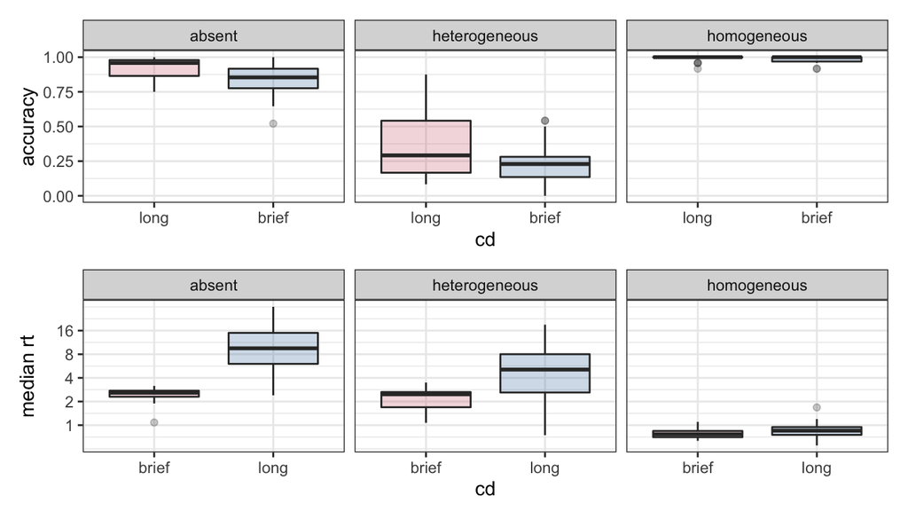

### 1.1.2 Saccadic Strategy

First, we need to merge (join) the fixation and accuracy data, so that we can take only correct target absent trials. We will compute the proportion of fixations to the heterogeneous side of the display for each fixation number, over all trials made by a participant.

Create a facet plot of each individual’s strategy.

We can further summarise the data by creating a strategy measure, which is the proportion of all (2 - 6) fixations made by an observer over all trials.

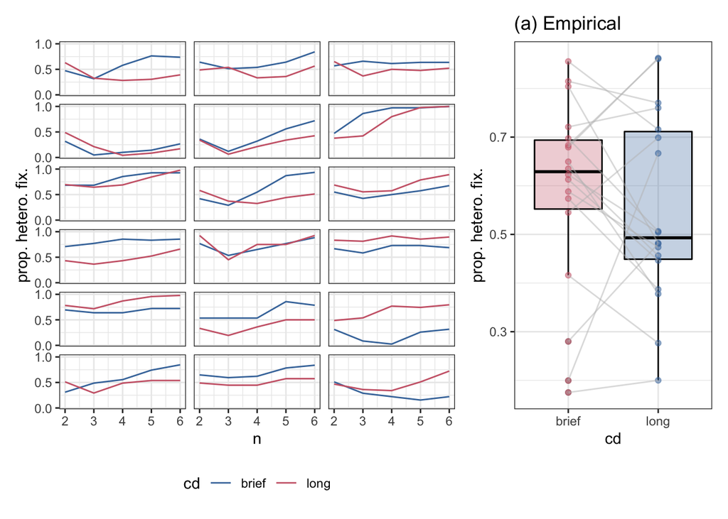

## 1.2 Bayesian Model of Saccadic Strategy

Summarise data so that we have one strategy score per trial per observer.

Note, as beta distributions are only defined over (0, 1), values of 0 and 1 are impossible. To get around this, we will set any such values to 0.001 and 0.999 respectively.

### 1.2.1 Define function for plotting model output

I will want to reuse this plotting code, so I will put it in a function here.

### 1.2.2 Define Priors

We will use $N(0, 1)$, weakly informative priors, illustrated in the plot below.

```r
model_priors <- c(
    prior(normal(0, 1), class = "b"))
```

```r
prior_model <- brm(
    data = d_strat,
    prop_hetero ~ 0 + cd + (cd | observer),
    family = "beta",
    sample_prior = "only",
    prior = model_priors,
    iter = 5000,
    control = list(adapt_delta = 0.95))
```

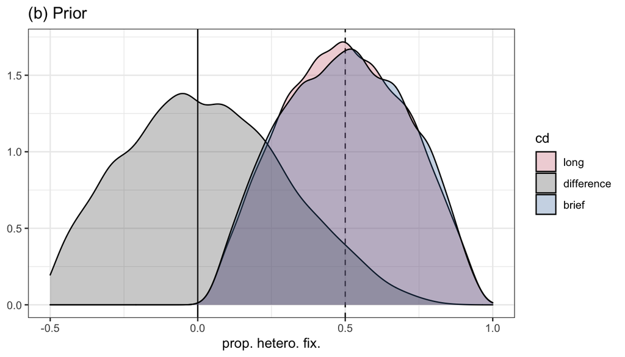

### 1.2.3 Power Analysis

We will carry out our power analysis by simulating our experiment assuming the distributions below.

```r
power_prior <- c(
  prior(normal(0.1, 0.25), class = "b", coef = "cdlong"),
    prior(normal(0.7, 0.25), class = "b", coef = "cdbrief"),
  prior(student_t(3, 0, 2), class = "sd"),
  prior(gamma(1, 10), class = "phi")
  )
```

We can now plot these distributions to check that they seem reasonable.

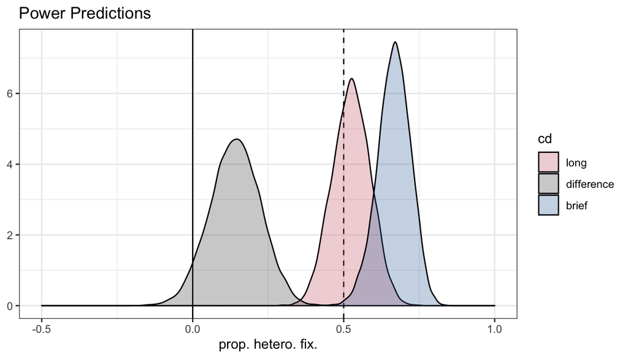

These corresponds to assuming distributions with the means presented below:

[output not shown]

We now generate multiple (=50) simulated datasets with 15 observers and 32 correct target absent trials. We then compute $p(\delta > 0| d)$, (the probablity, given the data, of seeing postive difference between the brief and long conditions) for each. The expected distribution of this statistic is shown below. We can see that in (almost?) every iteration, we get a value about 0.95.

And plot!

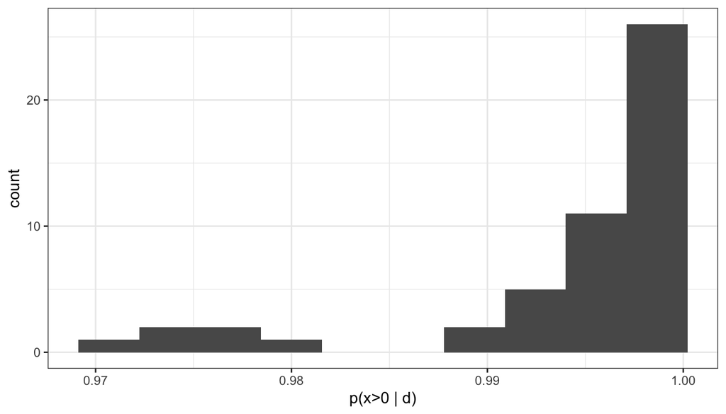

## 1.3 Compute and Plot Posterior

Now that we are confident that we have a sensible prior, and have carried out a power analysis, it is time to fit the model to the data.

```r
my_model <- brm(
  data = d_strat,
  prop_hetero ~ 0 + cd + (cd | observer),
  family = "beta",
    prior = model_priors,
    iter = 10000,
    control = list(adapt_delta = 0.95))
```

```
## recompiling to avoid crashing R session
```

```
##  Family: beta
##   Links: mu = logit; phi = identity
## Formula: prop_hetero ~ 0 + cd + (cd | observer)
##    Data: d_strat (Number of observations: 1520)
## Samples: 4 chains, each with iter = 10000; warmup = 5000; thin = 1;
##          total post-warmup samples = 20000
##
## Group-Level Effects:
## ~observer (Number of levels: 18)
##                       Estimate Est.Error l-95% CI u-95% CI Rhat Bulk_ESS Tail_ESS
## sd(Intercept)             1.07      0.21     0.75     1.55 1.00     4678     8307
## sd(cdlong)                1.00      0.20     0.69     1.47 1.00     4709     6967
## cor(Intercept,cdlong)    -0.49      0.19    -0.79    -0.06 1.00     4809     7209
##
## Population-Level Effects:
##         Estimate Est.Error l-95% CI u-95% CI Rhat Bulk_ESS Tail_ESS
## cdbrief     0.33      0.25    -0.16     0.83 1.00     3629     6125
## cdlong      0.25      0.24    -0.23     0.72 1.00     4491     6554
##
## Family Specific Parameters:
##     Estimate Est.Error l-95% CI u-95% CI Rhat Bulk_ESS Tail_ESS
## phi     1.71      0.06     1.60     1.83 1.00    16005    13746
##
## Samples were drawn using sampling(NUTS). For each parameter, Bulk_ESS
## and Tail_ESS are effective sample size measures, and Rhat is the potential
## scale reduction factor on split chains (at convergence, Rhat = 1).
```

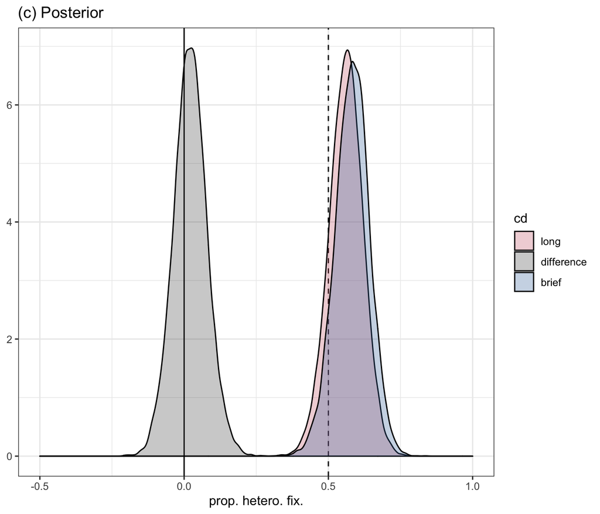

| long | long.lower | long.upper | brief | brief.lower | brief.upper | difference | difference.lower | difference.upper | .width | .point | .interval |
| --- | --- | --- | --- | --- | --- | --- | --- | --- | --- | --- | --- |
| 0.5618753 | 0.4457209 | 0.6763073 | 0.5831902 | 0.4664021 | 0.7014855 | 0.0208666 | -0.0949318 | 0.136971 | 0.95 | median | hdci |

We can conclude that $p(x>0 | d) = $ 0.6445.

# 2 Experiment 2: Reward

## 2.1 Descriptive Statistics

### 2.1.1 Accuracy and Reaction Time

After plotting the accuracy data, incorrect trials are removed from all further analysis.

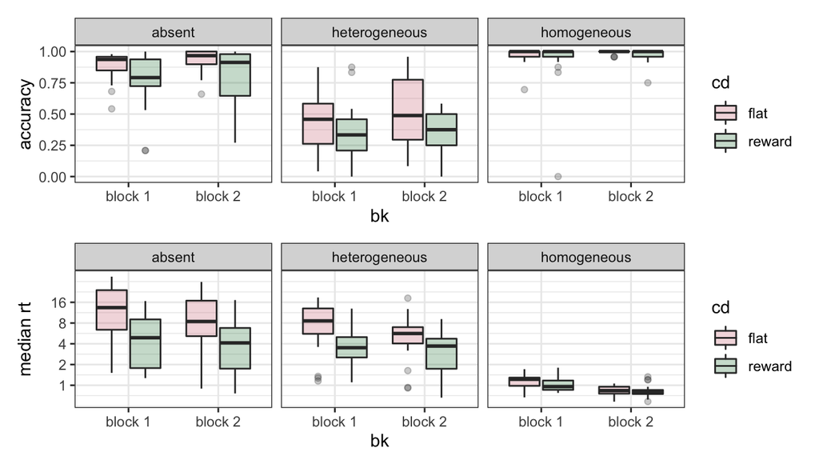

## 2.2 Saccadic Strategy

First, we need to merge (join) the fixation and accuracy data, so that we can take only correct target absent trials. We will compute the proportion of fixations to the heterogeneous side of the display for each fixation number, over all trials made by a participant.

Create a facet plot of each individual’s strategy.

We can further summarise the data by creating a strategy measure, which is the proportion of all (2 - 6) fixations made by an observer over all trials.

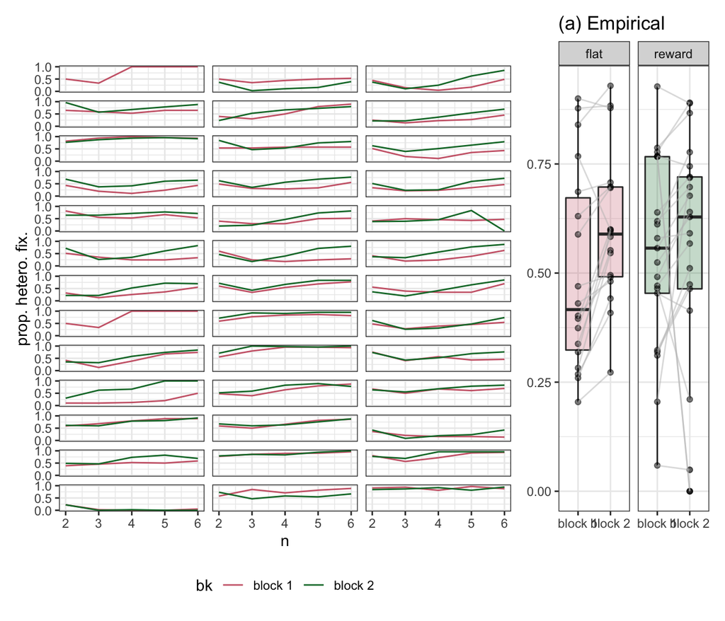

## 2.3 Bayesian Model of Saccadic Strategy

Summarise data so tha we have one strategy score per trial per observer.

Note, as beta distributions are only defined over (0, 1), values of 0 and 1 are impossible. To get around this, we will set any such values to 0.001 and 0.999 respectively.

### 2.3.1 Define Priors

We will use the same priors, and model structure, as above.

```r
model_priors <- c(
    prior(normal(0, 1), class = "b"))
```

```r
prior_model <- brm(
    data = d_strat,
    prop_hetero ~ 0 + cd + (cd | observer),
    sample_prior = "only",
    family = "beta",
    prior = model_priors,
    iter = 10000,
    control = list(adapt_delta = 0.95))
```

And plot, to see if it looks reasonable.

### 2.3.2 Power Analysis

We will carry out our power analysis by simulating our experiment assuming the distributions below.

We can now plot these distributions to check that they seem reasonable.

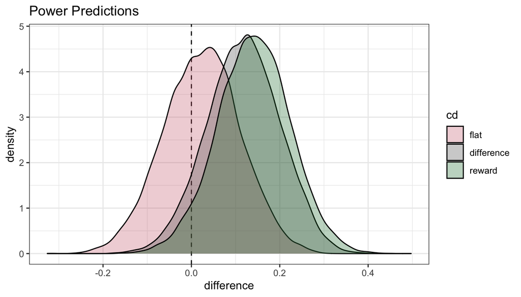

Next, we write a function to generate a simulated dataset.

Finally, we run this a number of times (50) to see the distribution of $p(\delta > 0| d)$ assuming 15 observers and 32 correct target absent trials.

And plot!

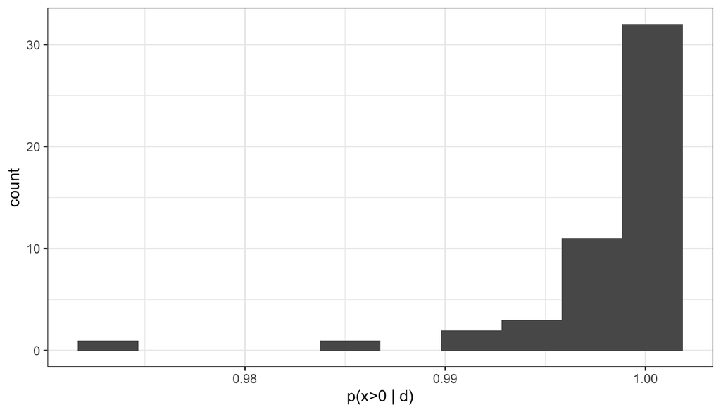

```
## # A tibble: 1 x 1
##   over_90
##     <int>
## 1      50
```

```
## # A tibble: 3 x 2
##   cd      mean_ph
##   <chr>     <dbl>
## 1 flat      0.535
## 2 initial   0.516
## 3 reward    0.567
```

## 2.4 Now refit model using data

```
##  Family: beta
##   Links: mu = logit; phi = identity
## Formula: prop_hetero ~ 0 + cd + (cd | observer)
##    Data: d_strat (Number of observations: 3025)
## Samples: 4 chains, each with iter = 10000; warmup = 5000; thin = 1;
##          total post-warmup samples = 20000
##
## Group-Level Effects:
## ~observer (Number of levels: 39)
##                         Estimate Est.Error l-95% CI u-95% CI Rhat Bulk_ESS
## sd(Intercept)               0.87      0.11     0.68     1.11 1.00     3523
## sd(cdreward)                0.48      0.14     0.25     0.80 1.00     6572
## sd(cdflat)                  0.35      0.10     0.18     0.56 1.00     7983
## cor(Intercept,cdreward)     0.01      0.24    -0.46     0.48 1.00     8965
## cor(Intercept,cdflat)      -0.57      0.20    -0.87    -0.10 1.00    13059
## cor(cdreward,cdflat)        0.00      0.46    -0.83     0.83 1.00     2521
##                         Tail_ESS
## sd(Intercept)               7210
## sd(cdreward)               10493
## sd(cdflat)                 10294
## cor(Intercept,cdreward)    12397
## cor(Intercept,cdflat)      13901
## cor(cdreward,cdflat)        6548
##
## Population-Level Effects:
##           Estimate Est.Error l-95% CI u-95% CI Rhat Bulk_ESS Tail_ESS
## cdinitial     0.02      0.14    -0.26     0.29 1.00     1966     3239
## cdreward      0.20      0.18    -0.17     0.55 1.00     2749     5122
## cdflat        0.39      0.13     0.12     0.65 1.00     2779     5002
##
## Family Specific Parameters:
##     Estimate Est.Error l-95% CI u-95% CI Rhat Bulk_ESS Tail_ESS
## phi     1.86      0.04     1.78     1.95 1.00    25447    15295
##
## Samples were drawn using sampling(NUTS). For each parameter, Bulk_ESS
## and Tail_ESS are effective sample size measures, and Rhat is the potential
## scale reduction factor on split chains (at convergence, Rhat = 1).
```

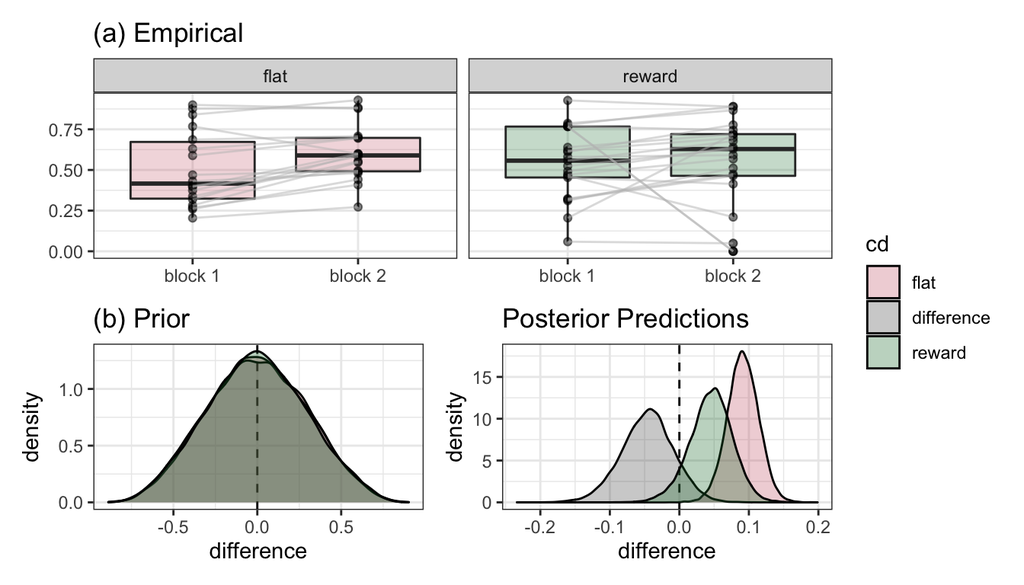

What is the the probability of a difference > 0, given the data?

```
## # A tibble: 1 x 1
##   prob_diff_greater_zero
##                    <dbl>
## 1                  0.109
```

```
## # A tibble: 1 x 12
##     flat flat.lower flat.upper reward reward.lower reward.upper difference
##    <dbl>      <dbl>      <dbl>  <dbl>        <dbl>        <dbl>      <dbl>
## 1 0.0913     0.0460      0.135 0.0466      -0.0160        0.106    -0.0449
## # … with 5 more variables: difference.lower <dbl>, difference.upper <dbl>,
## #   .width <dbl>, .point <chr>, .interval <chr>
```

## 2.5 Original Pre-Registered Analysis

We original pre-registered an analysis plan for this experiment using frequentist statistics. The results of this planned analysis are presented here.

### 2.5.1 Accuracy

```
## Linear mixed model fit by REML. t-tests use Satterthwaite's method [
## lmerModLmerTest]
## Formula: accuracy ~ bk * cd + (1 | observer)
##    Data: d_lmer_acc
##
## REML criterion at convergence: -137.2
##
## Scaled residuals:
##     Min      1Q  Median      3Q     Max
## -3.7596 -0.3331  0.0032  0.4835  2.3775
##
## Random effects:
##  Groups   Name        Variance Std.Dev.
##  observer (Intercept) 0.006457 0.08036
##  Residual             0.003678 0.06065
## Number of obs: 78, groups:  observer, 39
##
## Fixed effects:
##                     Estimate Std. Error        df t value Pr(>|t|)
## (Intercept)         0.796026   0.023729 52.634479  33.547  < 2e-16 ***
## bkblock 2           0.043949   0.020215 37.000000   2.174  0.03617 *
## cdreward           -0.091066   0.032337 52.634479  -2.816  0.00683 **
## bkblock 2:cdreward -0.009082   0.027549 37.000000  -0.330  0.74350
## ---
## Signif. codes:  0 '***' 0.001 '**' 0.01 '*' 0.05 '.' 0.1 ' ' 1
##
## Correlation of Fixed Effects:
##             (Intr) bkblc2 cdrwrd
## bkblock 2   -0.426
## cdreward    -0.734  0.313
## bkblck2:cdr  0.313 -0.734 -0.426
```

```
## Type III Analysis of Variance Table with Satterthwaite's method
##         Sum Sq  Mean Sq NumDF DenDF F value   Pr(>F)
## bk    0.030104 0.030104     1    37  8.1851 0.006907 **
## cd    0.039275 0.039275     1    37 10.6788 0.002344 **
## bk:cd 0.000400 0.000400     1    37  0.1087 0.743499
## ---
## Signif. codes:  0 '***' 0.001 '**' 0.01 '*' 0.05 '.' 0.1 ' ' 1
```

### 2.5.2 Median Reaction Time

```
## Linear mixed model fit by REML. t-tests use Satterthwaite's method [
## lmerModLmerTest]
## Formula: median_rt ~ bk * cd + (1 | observer)
##    Data: d_lmer_rt
##
## REML criterion at convergence: 434.4
##
## Scaled residuals:
##     Min      1Q  Median      3Q     Max
## -2.2991 -0.3078 -0.0809  0.3153  3.2528
##
## Random effects:
##  Groups   Name        Variance Std.Dev.
##  observer (Intercept) 26.257   5.124
##  Residual              5.393   2.322
## Number of obs: 78, groups:  observer, 39
##
## Fixed effects:
##                    Estimate Std. Error      df t value Pr(>|t|)
## (Intercept)         11.4244     1.3260 43.8324   8.616 5.54e-11 ***
## bkblock 2           -3.4926     0.7741 37.0000  -4.512 6.30e-05 ***
## cdreward            -7.1036     1.8071 43.8324  -3.931 0.000297 ***
## bkblock 2:cdreward   2.9688     1.0549 37.0000   2.814 0.007786 **
## ---
## Signif. codes:  0 '***' 0.001 '**' 0.01 '*' 0.05 '.' 0.1 ' ' 1
##
## Correlation of Fixed Effects:
##             (Intr) bkblc2 cdrwrd
## bkblock 2   -0.292
## cdreward    -0.734  0.214
## bkblck2:cdr  0.214 -0.734 -0.292
```

```
## Type III Analysis of Variance Table with Satterthwaite's method
##       Sum Sq Mean Sq NumDF DenDF F value    Pr(>F)
## bk    78.174  78.174     1    37 14.4957 0.0005119 ***
## cd    57.004  57.004     1    37 10.5701 0.0024528 **
## bk:cd 42.713  42.713     1    37  7.9202 0.0077858 **
## ---
## Signif. codes:  0 '***' 0.001 '**' 0.01 '*' 0.05 '.' 0.1 ' ' 1
```

[output not shown]

[output not shown]

### 2.5.3 Search Efficiency

```
## fixed-effect model matrix is rank deficient so dropping 3 columns / coefficients
```

```
## Linear mixed model fit by REML. t-tests use Satterthwaite's method [
## lmerModLmerTest]
## Formula: median_search_ef ~ bk * cd + (1 | observer)
##    Data: d_lmer_se
##
## REML criterion at convergence: 2
##
## Scaled residuals:
##     Min      1Q  Median      3Q     Max
## -2.0444 -0.4745  0.0963  0.4609  1.4285
##
## Random effects:
##  Groups   Name        Variance Std.Dev.
##  observer (Intercept) 0.05182  0.2276
##  Residual             0.02207  0.1486
## Number of obs: 78, groups:  observer, 39
##
## Fixed effects:
##             Estimate Std. Error       df t value Pr(>|t|)
## (Intercept)  0.50256    0.04353 50.82578  11.546 8.07e-16 ***
## bkblock 2    0.13314    0.04749 43.21037   2.804  0.00754 **
## cdreward    -0.10718    0.06224 49.94386  -1.722  0.09125 .
## ---
## Signif. codes:  0 '***' 0.001 '**' 0.01 '*' 0.05 '.' 0.1 ' ' 1
##
## Correlation of Fixed Effects:
##           (Intr) bkblc2
## bkblock 2 -0.274
## cdreward   0.000 -0.706
## fit warnings:
## fixed-effect model matrix is rank deficient so dropping 3 columns / coefficients
```

```
## Missing cells for: bkblock 2:cdinitial, bkblock 1:cdreward, bkblock 1:cdflat.
## Interpret type III hypotheses with care.
```

```
## Type III Analysis of Variance Table with Satterthwaite's method
##         Sum Sq  Mean Sq NumDF  DenDF F value   Pr(>F)
## bk    0.173494 0.173494     1 43.210  7.8604 0.007539 **
## cd    0.065451 0.065451     1 49.944  2.9654 0.091255 .
## bk:cd
## ---
## Signif. codes:  0 '***' 0.001 '**' 0.01 '*' 0.05 '.' 0.1 ' ' 1
```

### 2.5.4 Discussion

The results are consistent with the analysis presented in the paper

# 3 Time-course Analysis

I will now look to see what happens to search strategy over time: both on the scale of an individual trial, within and across blocks, and between experimental condition! First, I will fit one model to the data from both experiments.

## 3.1 Prior Predictions

```r
model_priors <- c(
    prior(normal(0, 1.0), class = "b"))

m_prior <- brm(
    data = d_strat,
    hetero_fix ~ (0 + cd) * (0 + n) * bk * ts  +
      (ts + n | observer) ,
    family = "bernoulli",
    sample_prior = "only",
    prior = model_priors,
    chains = 1)
saveRDS(m_prior, "models/my_prior.model")
m_prior <- readRDS("models/my_prior.model")
```

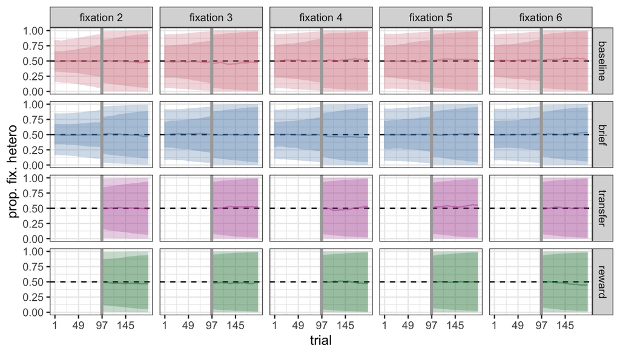

## 3.2 Posterior Predictions

```r
m_posterior <- brm(
    data = d_strat,
    hetero_fix ~ (0 + cd) * (0 + n) * bk * ts  +
     (ts + n | observer) ,
    family = "bernoulli",
    prior = model_priors,
    chains = 4)

m_posterior <- add_criterion(m_posterior, c("loo", "waic"))

saveRDS(m_posterior, "models/my_posterior.model")
m_posterior <- readRDS("models/my_posterior.model")
```

```
##  Family: bernoulli
##   Links: mu = logit
## Formula: hetero_fix ~ (0 + cd) * (0 + n) * bk * ts + (ts + n | observer)
##    Data: d_strat (Number of observations: 21830)
## Samples: 4 chains, each with iter = 2000; warmup = 1000; thin = 1;
##          total post-warmup samples = 4000
##
## Group-Level Effects:
## ~observer (Number of levels: 57)
##                   Estimate Est.Error l-95% CI u-95% CI Rhat Bulk_ESS
## sd(Intercept)         0.94      0.11     0.75     1.17 1.00     1613
## sd(ts)                0.57      0.07     0.45     0.72 1.00     1201
## sd(n3)                0.69      0.09     0.54     0.87 1.00     2154
## sd(n4)                0.91      0.10     0.73     1.12 1.00     1761
## sd(n5)                0.97      0.11     0.78     1.21 1.00     1756
## sd(n6)                0.95      0.11     0.75     1.21 1.00     1994
## cor(Intercept,ts)    -0.56      0.11    -0.74    -0.33 1.00     1481
## cor(Intercept,n3)     0.13      0.15    -0.17     0.42 1.00     1794
## cor(ts,n3)            0.20      0.15    -0.10     0.48 1.00     1961
## cor(Intercept,n4)     0.06      0.14    -0.21     0.34 1.00     1472
## cor(ts,n4)            0.20      0.14    -0.08     0.45 1.00     1776
## cor(n3,n4)            0.91      0.04     0.82     0.97 1.00     2159
## cor(Intercept,n5)    -0.10      0.14    -0.35     0.18 1.00     1426
## cor(ts,n5)            0.27      0.13    -0.01     0.51 1.00     1736
## cor(n3,n5)            0.79      0.07     0.63     0.91 1.00     1774
## cor(n4,n5)            0.94      0.03     0.88     0.98 1.00     2686
## cor(Intercept,n6)    -0.18      0.14    -0.43     0.10 1.00     1778
## cor(ts,n6)            0.25      0.14    -0.03     0.50 1.00     1843
## cor(n3,n6)            0.64      0.10     0.42     0.82 1.00     1607
## cor(n4,n6)            0.84      0.06     0.72     0.93 1.00     2136
## cor(n5,n6)            0.95      0.03     0.88     0.99 1.00     2806
##                   Tail_ESS
## sd(Intercept)         2986
## sd(ts)                2123
## sd(n3)                2775
## sd(n4)                2300
## sd(n5)                2385
## sd(n6)                2490
## cor(Intercept,ts)     2416
## cor(Intercept,n3)     2871
```

[output cut: 166 more lines]

```
## cdtransfer:n3:bkblock2:ts     7360     2959
## cdreward:n3:bkblock2:ts       3542     3317
## cdbaseline:n4:bkblock2:ts     3334     3047
## cdtransfer:n4:bkblock2:ts     6778     3096
## cdreward:n4:bkblock2:ts       4130     3291
## cdbaseline:n5:bkblock2:ts     3020     2967
## cdtransfer:n5:bkblock2:ts     7536     2672
## cdreward:n5:bkblock2:ts       4061     3303
## cdbaseline:n6:bkblock2:ts     3873     3116
## cdtransfer:n6:bkblock2:ts     7429     2935
## cdreward:n6:bkblock2:ts       3884     3133
##
## Samples were drawn using sampling(NUTS). For each parameter, Bulk_ESS
## and Tail_ESS are effective sample size measures, and Rhat is the potential
## scale reduction factor on split chains (at convergence, Rhat = 1).
```

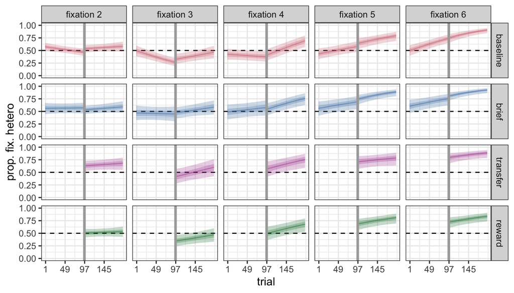

```
##    observer                cd            bk                  t
##  Length:21830       brief   :3509   Length:21830       Min.   :  1.00
##  Class :character   baseline:9378   Class :character   1st Qu.: 49.00
##  Mode  :character   transfer:2026   Mode  :character   Median : 97.00
##                     reward  :6917                      Mean   : 97.23
##                                                        3rd Qu.:145.00
##                                                        Max.   :192.00
##  n          hetero_fix           ts         targ_side
##  2:4545   Min.   :0.0000   Min.   :0.000   Length:21830
##  3:4486   1st Qu.:0.0000   1st Qu.:0.500   Class :character
##  4:4387   Median :1.0000   Median :1.000   Mode  :character
##  5:4258   Mean   :0.5592   Mean   :1.002
##  6:4154   3rd Qu.:1.0000   3rd Qu.:1.500
##           Max.   :1.0000   Max.   :1.990
##        rt              acc
##  Min.   : 0.271   Min.   :1
##  1st Qu.: 2.841   1st Qu.:1
##  Median : 6.401   Median :1
##  Mean   : 9.645   Mean   :1
##  3rd Qu.:13.027   3rd Qu.:1
##  Max.   :53.535   Max.   :1
```

## 3.3 Can we easily simplify the model?

I now fit simpler models, removing either one of the four variables, or the four-way interaction.

```
## recompiling to avoid crashing R session
```

```
## recompiling to avoid crashing R session
```

| x |
| --- |
| 0.4000746 |

| x |
| --- |
| 0.0651793 |

| x |
| --- |
| 2e-07 |

| x |
| --- |
| 0.4601177 |

| x |
| --- |
| 0.0746281 |

| x |
| --- |
| 80 |
| 40 |
| 40 |
| 20 |
| 16 |